# Homework 01

## Question 1 (Least squares and matrix calculations)

Set the random seed to 43201. Generate $n=100$ observations with $p=5$ predictors according to

$$x_{ij}\overset{\mathrm{iid}}{\sim}N(0,1),
\qquad
\varepsilon_i\overset{\mathrm{iid}}{\sim}N(0,0.7^2),$$

with all predictors and errors generated independently. Let

$$\mathbf X
=
\begin{bmatrix}
\mathbf 1 & \mathbf x_1 & \cdots & \mathbf x_5
\end{bmatrix},
\qquad
\boldsymbol\beta
=
(3,1.4,-0.9,0.7,0,1.1)^{\mathsf T},$$

and generate

$$\mathbf y=\mathbf X\boldsymbol\beta+\boldsymbol\varepsilon.$$

1. Generate the data and report the dimensions and rank of $\mathbf X$. Calculate the least-squares estimate $\widehat{\boldsymbol\beta}$ using a numerically stable least-squares routine, without explicitly calculating $(\mathbf X^{\mathsf T}\mathbf X)^{-1}$. Compare the estimates with the coefficients used to generate the data.
2. Calculate the fitted values, the residual vector $\mathbf r=\mathbf y-\mathbf X\widehat{\boldsymbol\beta}$, and the training root mean squared error

$$\operatorname{RMSE}
=
\left(
\frac{1}{n}\sum_{i=1}^{n}r_i^2
\right)^{1/2}.$$

3. Report $\lVert\mathbf X^{\mathsf T}\mathbf r\rVert_\infty$. Explain why this value should be close to zero and what it tells us about the residual vector.

### My answer

```python
import numpy as np

rng = np.random.default_rng(43201)
n, p = 100, 5

x = rng.normal(size=(n, p))
X = np.column_stack([np.ones(n), x])
beta = np.array([3.0, 1.4, -0.9, 0.7, 0.0, 1.1])

epsilon = rng.normal(0.0, 0.7, size=n)
y = X @ beta + epsilon

# SVD-based solve, so it never forms (X^T X)^{-1}.
beta_hat, _, rank, _ = np.linalg.lstsq(X, y, rcond=None)

fitted = X @ beta_hat
r = y - fitted
rmse = np.sqrt(np.mean(r**2))
normal_eq = np.max(np.abs(X.T @ r))

print("dimensions of X:", X.shape)
print("rank of X:", rank)
print("truth vs estimate:")
print(np.column_stack([beta, beta_hat]).round(4))
print("training RMSE:", round(rmse, 4))
print("||X^T r||_inf:", normal_eq)
```

```
dimensions of X: (100, 6)
rank of X: 6
truth vs estimate:
[[ 3.      2.9731]
 [ 1.4     1.324 ]
 [-0.9    -0.8415]
 [ 0.7     0.7204]
 [ 0.     -0.0831]
 [ 1.1     1.1651]]
training RMSE: 0.6463
||X^T r||_inf: 1.4787506805662469e-12
```

**Part a.** $\mathbf X$ is $100\times 6$: one intercept column plus the five simulated predictors. A Gaussian design of this shape has full column rank with probability one, and the computed rank is indeed $6$. Solving with `np.linalg.lstsq` avoids the normal equations entirely, since it works from the SVD of $\mathbf X$ rather than inverting $\mathbf X^{\mathsf T}\mathbf X$ (which would square the condition number).

The estimates come out to roughly
$$\widehat{\boldsymbol\beta}\approx(2.97,\ 1.32,\ -0.84,\ 0.72,\ -0.08,\ 1.17)^{\mathsf T}.$$
They are close to the generating values but not equal, which is expected: this is a single noise realization, not the population. The estimate for $x_4$ lands near $0$, matching its true coefficient of exactly $0$.

**Part b.** The fitted values are $\widehat{\mathbf y}=\mathbf X\widehat{\boldsymbol\beta}$ and the residuals are $\mathbf r=\mathbf y-\widehat{\mathbf y}$. The training RMSE is about $0.646$, close to the noise standard deviation $0.7$ used to generate the data, as it should be.

## Question 2 (Gaussian likelihood for linear regression)

Continue with the data from Question 1. Suppose

$$\mathbf Y\mid\mathbf X
\sim
N_n\left(\mathbf X\boldsymbol\beta,\sigma^2\mathbf I_n\right).$$

The log-likelihood, including the constant term, is

$$\ell(\boldsymbol\beta,\sigma^2)
=
-\frac{n}{2}\log(2\pi\sigma^2)
-\frac{1}{2\sigma^2}
(\mathbf y-\mathbf X\boldsymbol\beta)^{\mathsf T}
(\mathbf y-\mathbf X\boldsymbol\beta).$$

1. For fixed $\sigma^2$, explain why maximizing $\ell(\boldsymbol\beta,\sigma^2)$ over $\boldsymbol\beta$ is equivalent to minimizing the residual sum of squares. What does this imply about the maximum-likelihood estimate of $\boldsymbol\beta$?
2. For fixed $\boldsymbol\beta$, differentiate the log-likelihood with respect to $\sigma^2$ and derive its maximum-likelihood estimate. Calculate this estimate at $\widehat{\boldsymbol\beta}$ and compare it with the unbiased estimate of $\sigma^2$. Explain why the two denominators differ.
3. Let

$$\mathbf e_{x_2}=(0,0,1,0,0,0)^{\mathsf T}.$$

Using the variance estimate from part b, plot

$$\ell\left(
\widehat{\boldsymbol\beta}+t\mathbf e_{x_2},
\widehat{\sigma}_{\mathrm{MLE}}^2
\right)$$

over a grid of $t$ values from $-1.25$ to $1.25$. State where the maximum occurs and explain why this agrees with the least-squares result.

### My answer

**Part a.** Hold $\sigma^2$ fixed. The term $-\tfrac{n}{2}\log(2\pi\sigma^2)$ is constant in $\boldsymbol\beta$, and the remaining term is $-\tfrac{1}{2\sigma^2}\operatorname{RSS}(\boldsymbol\beta)$ with a negative multiplier. So
$$\operatorname*{argmax}_{\boldsymbol\beta}\ \ell(\boldsymbol\beta,\sigma^2)
=\operatorname*{argmin}_{\boldsymbol\beta}\ \lVert\mathbf y-\mathbf X\boldsymbol\beta\rVert_2^2.$$
The MLE of $\boldsymbol\beta$ is therefore exactly the least-squares estimate from Question 1, regardless of the value of $\sigma^2$.

**Part b.** Write $v=\sigma^2$ and $\operatorname{RSS}=\lVert\mathbf y-\mathbf X\boldsymbol\beta\rVert_2^2$. Then
$$\ell(\boldsymbol\beta,v)=-\frac{n}{2}\log(2\pi v)-\frac{\operatorname{RSS}}{2v},
\qquad
\frac{\partial\ell}{\partial v}=-\frac{n}{2v}+\frac{\operatorname{RSS}}{2v^2}.$$
Setting the derivative to zero gives $\widehat\sigma^2_{\mathrm{MLE}}=\operatorname{RSS}/n$. The second derivative at that point is $-n/(2\widehat v^2)<0$, so it is a maximum. The unbiased estimator instead divides by the residual degrees of freedom, $\widehat\sigma^2_{\text{unb}}=\operatorname{RSS}/(n-6)$, because $\mathbb E(\operatorname{RSS})=(n-6)\sigma^2$ once six coefficients have been fit. The MLE divides by $n$ (it maximizes the likelihood directly and ignores the lost degrees of freedom), so it is biased slightly downward; the unbiased version corrects for the six estimated parameters.

```
sigma2_MLE: 0.4178
sigma2_unbiased: 0.4444
maximizing t: 0.0
```

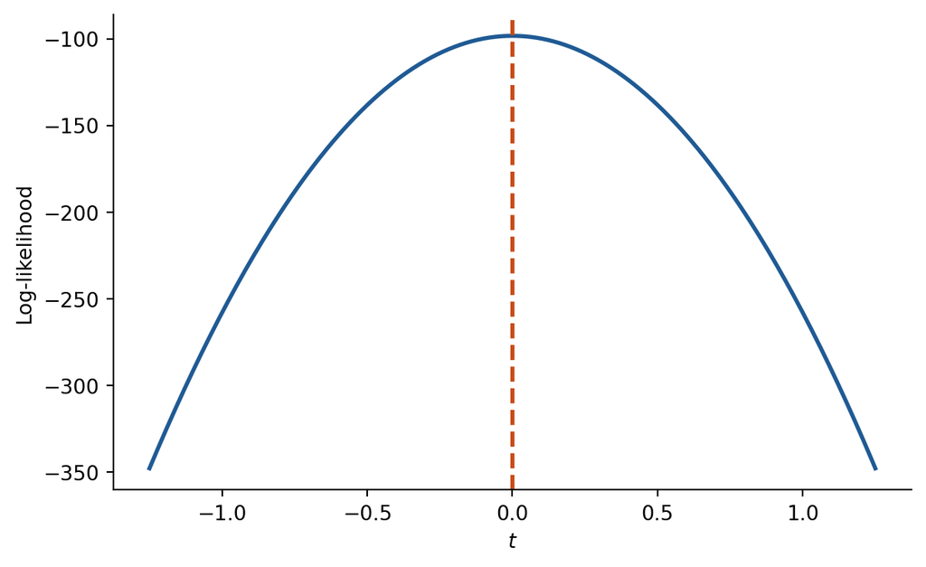

Log-likelihood profile along the x2 coordinate.

```python
import matplotlib.pyplot as plt

rss = r @ r
sigma2_mle = rss / n
sigma2_unb = rss / (n - X.shape[1])

def log_likelihood(b, s2):
    resid = y - X @ b
    return -n / 2 * np.log(2 * np.pi * s2) - (resid @ resid) / (2 * s2)

e_x2 = np.array([0.0, 0.0, 1.0, 0.0, 0.0, 0.0])
t_grid = np.linspace(-1.25, 1.25, 251)
profile = np.array([log_likelihood(beta_hat + t * e_x2, sigma2_mle) for t in t_grid])

print("sigma2_MLE:", round(sigma2_mle, 4))
print("sigma2_unbiased:", round(sigma2_unb, 4))
print("maximizing t:", round(t_grid[np.argmax(profile)], 4))

fig, ax = plt.subplots(figsize=(7, 4.2))
ax.plot(t_grid, profile, color="#1F5A94", linewidth=2)
ax.axvline(0, color="#C84A16", linestyle="--", linewidth=2)
ax.set(xlabel=r"$t$", ylabel="Log-likelihood")
ax.spines[["top", "right"]].set_visible(False)
plt.show()
```

The two variance estimates come out to about $\widehat\sigma^2_{\mathrm{MLE}}\approx0.418$ and $\widehat\sigma^2_{\text{unb}}\approx0.444$. The unbiased one is a bit larger, exactly because its denominator $n-6=94$ is smaller than $n=100$.

**Part c.** $t=0$ corresponds to $\widehat{\boldsymbol\beta}$ itself. Moving $t$ away from $0$ perturbs only the $x_2$ coefficient, which can only increase the RSS (the least-squares fit already minimized it), so the log-likelihood drops on both sides. The plot peaks at $t=0$, which is the same answer least squares gave: the MLE for $\boldsymbol\beta$ is the least-squares solution.

## Question 3 (Starting values in nonconvex optimization)

Consider the function

$$f(x)=\exp(1.5x)-3(x+6)^2-0.05x^3,$$

with derivative

$$f'(x)=1.5\exp(1.5x)-6(x+6)-0.15x^2.$$

1. Plot $f(x)$ over the interval $[-40,7]$. Based on the plot, describe the important features of the objective function that may affect numerical optimization.
2. Use BFGS to minimize $f(x)$ twice, starting at $x^{(0)}=-15$ and $x^{(0)}=0$. Supply $f'(x)$ to the optimizer. For each run, report the final value of $x$, the final objective value, $|f'(x)|$, and whether the optimizer reported convergence.
3. Explain why the two runs can converge to different answers. Which run gives the lower objective value? What additional evidence would be needed before claiming that this point is the global minimum?

### My answer

```
start=-15.0  x=-32.64911  f(x)=-390.38577  |f'(x)|=2.84e-14  converged=True
start=  0.0  x= 2.34997  f(x)=-175.86262  |f'(x)|=8.13e-06  converged=True
```

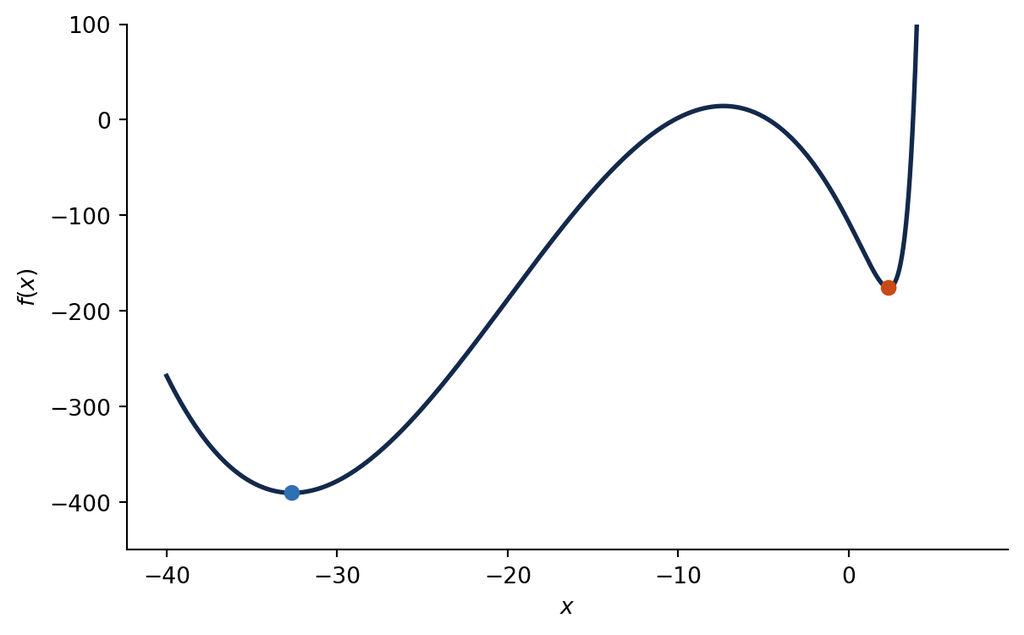

Nonconvex objective with the two BFGS solutions marked.

```python
from scipy.optimize import minimize

def objective(x):
    return np.exp(1.5 * x) - 3 * (x + 6) ** 2 - 0.05 * x**3

def gradient(x):
    return 1.5 * np.exp(1.5 * x) - 6 * (x + 6) - 0.15 * x**2

x_grid = np.linspace(-40, 7, 1200)

fig, ax = plt.subplots(figsize=(7, 4.2))
ax.plot(x_grid, objective(x_grid), color="#13294B", linewidth=2)
# Clip only the display so both low regions stay visible; the optimizer sees f as-is.
ax.set(ylim=(-450, 100), xlabel=r"$x$", ylabel=r"$f(x)$")
ax.spines[["top", "right"]].set_visible(False)

starts = [-15.0, 0.0]
results = []
for s in starts:
    res = minimize(
        lambda v: objective(v[0]),
        x0=np.array([s]),
        jac=lambda v: np.array([gradient(v[0])]),
        method="BFGS",
    )
    results.append(res)
    print(
        f"start={s:5.1f}  x={res.x[0]: .5f}  f(x)={res.fun: .5f}  "
        f"|f'(x)|={abs(gradient(res.x[0])):.2e}  converged={res.success}"
    )

ax.scatter(
    [res.x[0] for res in results],
    [res.fun for res in results],
    color=["#2F6FB3", "#C84A16"],
    zorder=3,
)
plt.show()
```

**Part a.** Over $[-40,7]$ the function has two separate valleys (two local minima) split by a local maximum, and it shoots up steeply on the right as the $\exp(1.5x)$ term takes over. That exponential blow-up is why I clipped the vertical axis for display only, so both valleys stay readable. The takeaway for optimization: because there is more than one local minimum, a gradient-based method sees only local slope information and will settle into whichever basin its starting point falls in.

**Part b.** The two runs give:

- start $x^{(0)}=-15$: converges to $x\approx-32.649$, $f\approx-390.386$, $|f'|\approx3\times10^{-14}$, converged.
- start $x^{(0)}=0$: converges to $x\approx2.350$, $f\approx-175.863$, $|f'|\approx8\times10^{-6}$, converged.

Both report success and both have essentially zero gradient, confirming each found a stationary local minimum.

**Part c.** They differ because each start sits in a different basin of attraction, and BFGS follows local curvature downhill from wherever it begins. The $x^{(0)}=-15$ run reaches the lower value ($-390.386$ vs $-175.863$), so it is the better of the two. But “lower of two runs” is not “global minimum.” To claim global optimality I would want to: analyze the limiting behavior as $x\to\pm\infty$ (here $f\to+\infty$ on the right from the exponential, and $f\to+\infty$ on the far left is worth checking against the $-0.05x^3$ term), find all roots of $f'(x)$, and compare $f$ at every stationary point. Many starting values or a dense grid give supporting evidence but do not by themselves prove there is no lower valley elsewhere.

## Question 4 (Nearly collinear predictors)

Continue with $\mathbf X$ and $\mathbf y$ from Question 1. Set the random seed to 43202 and generate

$$u_i\overset{\mathrm{iid}}{\sim}N(0,1),
\qquad i=1,\ldots,n.$$

Define

$$\mathbf x_6=\mathbf x_1+10^{-4}\mathbf u,
\qquad
\mathbf X_+
=
\begin{bmatrix}
\mathbf X & \mathbf x_6
\end{bmatrix},$$

and let

$$\mathbf y^\star=\mathbf y+10^{-3}\mathbf u.$$

Use a numerically stable least-squares routine throughout.

1. Fit $\mathbf y$ using $\mathbf X$ and $\mathbf X_+$. For each design matrix, report the condition number and training RMSE. For the augmented fit, also report the coefficients of $\mathbf x_1$ and $\mathbf x_6$.
2. Fit $\mathbf y^\star$ using $\mathbf X_+$. Report the changes in the coefficients of $\mathbf x_1$ and $\mathbf x_6$. Compare the two fitted-value vectors using their root mean squared difference and maximum absolute difference.
3. Use the identity

$$\mathbf y^\star-\mathbf y
=
10(\mathbf x_6-\mathbf x_1)$$

to explain why the fitted values change very little while the two coefficients change substantially. What does this example suggest about interpreting separate effects for nearly collinear predictors?

### My answer

```python
rng_q4 = np.random.default_rng(43202)
u = rng_q4.normal(size=n)

x6 = x[:, 0] + 1e-4 * u
X_plus = np.column_stack([X, x6])
y_star = y + 1e-3 * u

beta_X = np.linalg.lstsq(X, y, rcond=None)[0]
beta_aug = np.linalg.lstsq(X_plus, y, rcond=None)[0]
beta_pert = np.linalg.lstsq(X_plus, y_star, rcond=None)[0]

fitted_aug = X_plus @ beta_aug
fitted_pert = X_plus @ beta_pert
diff = fitted_pert - fitted_aug

print("cond(X):     ", round(np.linalg.cond(X), 3),
      " RMSE:", round(np.sqrt(np.mean((y - X @ beta_X) ** 2)), 4))
print("cond(X_plus):", round(np.linalg.cond(X_plus), 1),
      " RMSE:", round(np.sqrt(np.mean((y - fitted_aug) ** 2)), 4))
print("y   -> (b_x1, b_x6):", beta_aug[[1, 6]].round(3), " sum:", round(beta_aug[[1, 6]].sum(), 3))
print("y*  -> (b_x1, b_x6):", beta_pert[[1, 6]].round(3), " sum:", round(beta_pert[[1, 6]].sum(), 3))
print("coefficient change  :", (beta_pert[[1, 6]] - beta_aug[[1, 6]]).round(4))
print("fitted diff  RMSE:", round(np.sqrt(np.mean(diff**2)), 6),
      " max:", round(np.max(np.abs(diff)), 6))
```

```
cond(X):      1.453  RMSE: 0.6463
cond(X_plus): 20339.8  RMSE: 0.634
y   -> (b_x1, b_x6): [-1329.743  1331.06 ]  sum: 1.317
y*  -> (b_x1, b_x6): [-1339.743  1341.06 ]  sum: 1.317
coefficient change  : [-10.  10.]
fitted diff  RMSE: 0.000975  max: 0.002351
```

**Part a.** $\mathbf X$ is well conditioned (condition number $\approx1.45$), but $\mathbf X_+$ is not (condition number $\approx2\times10^{4}$). This is because $\mathbf x_6-\mathbf x_1=10^{-4}\mathbf u$, so the two columns are almost identical and the design now has a nearly flat direction in coefficient space. The training RMSE barely moves (about $0.646$ to $0.634$), but the separate coefficients of $\mathbf x_1$ and $\mathbf x_6$ blow up to large values with opposite signs (roughly $-1330$ and $+1331$ here). Their sum, however, stays near $1.32$, which is essentially the single $x_1$ coefficient from the original fit.

**Part b.** Refitting on $\mathbf y^\star$, the two coefficients change by exactly $\Delta\widehat\beta_1=-10$ and $\Delta\widehat\beta_6=+10$, while every other coefficient is unchanged up to rounding. Despite that huge swing, the fitted values move almost imperceptibly: RMS difference $\approx0.00097$ and max absolute difference $\approx0.0024$.

**Part c.** The identity explains it cleanly. Since $\mathbf x_6-\mathbf x_1=10^{-4}\mathbf u$,
$$\mathbf y^\star-\mathbf y=10^{-3}\mathbf u=10^{-3}\cdot\frac{\mathbf x_6-\mathbf x_1}{10^{-4}}=10(\mathbf x_6-\mathbf x_1).$$
So the entire change in the response lies in the $\mathbf x_6-\mathbf x_1$ direction. The augmented model can absorb it by pushing $\widehat\beta_1$ down by $10$ and $\widehat\beta_6$ up by $10$, which shifts the fit by exactly $10(\mathbf x_6-\mathbf x_1)=10^{-3}\mathbf u$, a change on the order of a thousandth. Big moves in the individual coefficients, tiny moves in predictions. The lesson: when predictors are nearly collinear, the data pin down their combined contribution (here $\widehat\beta_1+\widehat\beta_6$) but not their separate effects, so interpreting the individual coefficients as distinct “effects” is not trustworthy.

## Question 5 (Data preparation and summary statistics)

The file `data/data-manipulation.csv` is a small constructed data table containing an observation identifier, a group label, two numeric predictors, and a response. Some response values are missing. For analyses involving the response, use only observations with a recorded response. Do not replace a missing response with zero or a group mean.

1. Read the data and report its dimensions, column types, number of duplicated identifiers, and number of missing values in each column. Create an analysis table containing only observations with a recorded response, and define

$$\texttt{feature\_sum}=\texttt{x1}+\texttt{x2}.$$

2. For each group, report the number of observations, the mean response, and the mean of `feature_sum`. State clearly which observations these summaries describe.
3. Sort the analysis table by response from largest to smallest and report the first three rows, including `observation_id`, `group`, `response`, and `feature_sum`. Add code checks verifying that the number of retained rows equals the number of nonmissing responses in the original data, that the analysis table has no missing response values, and that its identifiers are unique.

### My answer

```python
import os
from pathlib import Path
import pandas as pd

# Find the file whether Quarto runs from the doc folder or the project root.
data_file = Path("data") / "data-manipulation.csv"
if not data_file.exists():
    doc_dir = Path(os.environ.get("QUARTO_DOCUMENT_PATH", "."))
    data_file = doc_dir / "data" / "data-manipulation.csv"

raw = pd.read_csv(data_file)

print("dimensions:", raw.shape)
print(raw.dtypes)
print("duplicated ids:", raw["observation_id"].duplicated().sum())
print("missing per column:")
print(raw.isna().sum())

# Drop missing responses (never impute); summaries use recorded rows only.
analysis = raw.dropna(subset=["response"]).copy()
analysis["feature_sum"] = analysis["x1"] + analysis["x2"]

group_summary = (
    analysis.groupby("group", as_index=False)
    .agg(
        observations=("response", "size"),
        mean_response=("response", "mean"),
        mean_feature_sum=("feature_sum", "mean"),
    )
)
print(group_summary.to_string(index=False))

top3 = (
    analysis.sort_values("response", ascending=False)
    .loc[:, ["observation_id", "group", "response", "feature_sum"]]
    .head(3)
)
print(top3.to_string(index=False))

n_recorded = raw["response"].notna().sum()
assert len(analysis) == n_recorded, "row count must equal number of recorded responses"
assert not analysis["response"].isna().any(), "analysis table must have no missing responses"
assert analysis["observation_id"].is_unique, "identifiers must be unique"
print("all checks passed")
```

```
dimensions: (24, 5)
observation_id        str
group                 str
x1                float64
x2                float64
response          float64
dtype: object
duplicated ids: 0
missing per column:
observation_id    0
group             0
x1                0
x2                0
response          3
dtype: int64
group  observations  mean_response  mean_feature_sum
    A             7       5.600000          3.600000
    B             7       7.602857          4.928571
    C             7       7.997143          6.585714
observation_id group  response  feature_sum
        obs-22     C      9.24          6.6
        obs-16     B      9.00          5.2
        obs-14     B      8.66          5.0
all checks passed
```

**Part a.** The raw table is $24\times 5$. The id and group columns read in as text, while `x1`, `x2`, and `response` are numeric. There are $0$ duplicated identifiers, and the only column with missing values is `response`, with $3$ missing. I build `analysis` by dropping those $3$ rows and then add `feature_sum = x1 + x2`, leaving $21$ observations. I do not impute the missing responses, since filling them with $0$ or a group mean would inject values that were never observed and would distort the group summaries below.

**Part b.** The per-group summaries, over recorded responses only, are:

| Group | Observations | Mean response | Mean `feature_sum` |
| --- | --- | --- | --- |
| A | 7 | 5.6000 | 3.6000 |
| B | 7 | 7.6029 | 4.9286 |
| C | 7 | 7.9971 | 6.5857 |

These describe only the $21$ observations with a recorded response, not all $24$ rows in the raw file, so they should be reported as summaries of the recorded-response subset rather than of the full table.

**Part c.** Sorting by response descending, the three largest recorded responses are:

| `observation_id` | Group | Response | `feature_sum` |
| --- | --- | --- | --- |
| `obs-22` | C | 9.24 | 6.6 |
| `obs-16` | B | 9.00 | 5.2 |
| `obs-14` | B | 8.66 | 5.0 |

The three `assert` statements confirm the analysis population is correct: the retained row count ($21$) equals the number of nonmissing responses in the raw data, no missing responses remain, and the identifiers are still unique. Writing the first check against `raw["response"].notna().sum()` rather than the literal $21$ keeps it valid even if the input file changes.

## Question 6 (Can 39 million Fitbit records represent US adults?)

[Patten et al. (2026)](https://doi.org/10.1038/s41591-026-04352-3) describe Fitbit data from 59,018 participants in the All of Us Research Program. The dataset spans 14 years and contains more than 39 million daily step records. Participants contributed data through one of two routes:

- Bring Your Own Device (BYOD): participants shared data from a Fitbit they already owned.
- Wearables Enhancing All of Us Research (WEAR): invited participants received a Fitbit at no cost.

In the general activity cohort, the BYOD and WEAR groups contained 32,035 and 22,474 participants, respectively. The BYOD value is listed first in each comparison below:

- 77.3% versus 55.1% reported being White;
- 6.1% versus 15.2% reported annual household income between $\$10{,}000$ and $\$25{,}000$; and
- median daily steps were 6,867 versus 5,797.

Suppose the target is the mean of the participant-specific average daily step counts among US adults during the study period, with each adult given equal weight. A researcher writes:

> “This dataset contains more than 39 million daily Fitbit records. Therefore, the average of all recorded step counts should provide an accurate estimate of mean daily activity among US adults.”
1. Are the 39 million daily records independent observations? What characteristics or behaviors could cause some participants to contribute more recorded days than others? Explain how averaging all recorded days would then weight participants unequally.
2. BYOD participants reported a median of 6,867 daily steps, compared with 5,797 among WEAR participants. Does this comparison show that already owning a Fitbit causes people to walk more? Explain your answer and give at least one plausible alternative explanation based on how participants entered the two groups.
3. A very large dataset can still produce a biased estimate of a population quantity when the people and observations entering the dataset are selected. Using this study, explain how selection of both participants and recorded days could make the observed data differ from the US adult population. Why might the naive average of all recorded daily step counts fail to estimate the stated target? You do not need to determine the direction of the bias.

### My answer

**Part a.** No, the 39 million records are not independent. They are repeated daily measurements nested within about 59,000 participants, and days from the same person are correlated because their health, job, routine, and environment carry over from one day to the next. Effectively there are far fewer than 39 million independent pieces of information. Participants also contribute very different numbers of days: someone enrolled longer, who wears and syncs the device consistently, has stable connectivity, and produces valid days will pile up many records, whereas illness, travel, irregular schedules, privacy concerns, or device failures cut a person’s count down. Taking a flat average over all recorded days then weights each participant by how many days they contributed. If day count is itself related to activity (for example, more engaged or healthier people both wear the device more and walk more), that record-weighted average systematically differs from the equal-per-person target.

**Part b.** No, it does not show a causal effect of Fitbit ownership. BYOD versus WEAR is not a randomized assignment; people sorted themselves into the two routes. The paper’s own demographics show the groups differ substantially (BYOD is whiter and has fewer low-income participants), so the two routes are drawing from different populations. A plausible alternative explanation: people who already bought a Fitbit tend to be wealthier, more health-conscious, and already more active, and that pre-existing difference, not the act of owning the device, drives the higher median steps. The step gap is confounded by who ends up in each group.

**Part c.** A US adult has to clear several selection gates before any of their steps appear in this data:

1. **Enroll in All of Us.** Participation is voluntary, so enrollees may differ from the general adult population in health, healthcare access, and willingness to join research.
2. **Enter via BYOD or WEAR.** BYOD requires already owning a compatible Fitbit; WEAR requires being invited and accepting a device.
3. **Consent and connect.** The participant must agree to share wearable data and successfully link an account.
4. **Keep producing valid days.** They must keep wearing and syncing the device, and each day must meet the study’s validity rules.

Selection at any gate that correlates with activity pulls the observed sample away from US adults as a whole. This is why sheer size does not rescue the naive average: a huge $n$ shrinks the random variation around the mean *of the observed participant-days*, but it does nothing about a systematic gap between those observations and the target population. The naive average fails the stated target on two counts. First, it is day-weighted rather than person-weighted, so it over-represents high-day contributors. Second, even after fixing the weighting to one-per-person, the participants themselves are a selected, non-representative slice of US adults. Free devices through WEAR remove the “must already own a Fitbit” barrier but leave every other gate (enrollment, invitation and acceptance, consent, connection, sustained use, valid days) in place. A defensible estimate would first summarize each participant’s own average, model the within-person dependence, and then reweight or calibrate toward the population using variables tied to participation and activity, and even that relies on assumptions and cannot fully undo selection on unmeasured factors.

### Source

Patten, T., Preble, E. A., Master, H., et al. (2026). [The All of Us Research Program’s wearables dataset](https://doi.org/10.1038/s41591-026-04352-3). *Nature Medicine*, 32, 2302-2310.